# Prediction Model

## Introduction

Using devices such as Jawbone Up, Nike FuelBand, and Fitbit it is now possible to collect a large amount of data about personal activity relatively inexpensively. These type of devices are part of the quantified self movement – a group of enthusiasts who take measurements about themselves regularly to improve their health, to find patterns in their behavior, or because they are tech geeks. One thing that people regularly do is quantify how much of a particular activity they do, but they rarely quantify how well they do it. In this project, our goal is to use data from accelerometers on the belt, forearm, arm, and dumbell of 6 participants. They were asked to perform barbell lifts correctly and incorrectly in 5 different ways. More information is available from the website here: http://groupware.les.inf.puc-rio.br/har (see the section on the Weight Lifting Exercise Dataset). Our goal for this project is to predict the manner in which they did the exercise. This is the “classe” variable in the training set.

Below is the code I used when creating the model, estimating the out-of-sample error, and making predictions.

## Data

The training data for this project are available here:

https://d396qusza40orc.cloudfront.net/predmachlearn/pml-training.csv

The test data are available here:

https://d396qusza40orc.cloudfront.net/predmachlearn/pml-testing.csv

The data for this project come from this source: http://groupware.les.inf.puc-rio.br/har

## Data cleaning

Load all the packages that will be used for the analysis and load data.

```r
library(caret)
```

```r
library(ggplot2)
library(reshape2)

# data urls
urlTraining <- "https://d396qusza40orc.cloudfront.net/predmachlearn/pml-training.csv"
urlValidation <- "https://d396qusza40orc.cloudfront.net/predmachlearn/pml-testing.csv"

# load data
dataset <- read.csv(urlTraining, header = T, na.strings = c("", "NA"))
validation <- read.csv(urlValidation, header = T, na.strings = c("", "NA"))
```

Explore data:

```r
# dataset dimension
dim(dataset)
```

```
## [1] 19622   160
```

```r
# NA columns
NA_cols = apply(dataset, 2, function(x) sum(is.na(x))); NA_cols = NA_cols[NA_cols > 0]
```

The dataset contains 19622 observations of 160 variables. By looking at the number of NAs per columns, we observe that 100 columns have observations that are almost always NAs. The names of these variables indicate that in fact these variables are summary data. We will remove these variables from the analysis. We will also remove the metadata (columns 1 to 7) which are irrelevant to the outcome.

```r
# remove mostly na columns (summary variables)
filteredData <- dataset[,-which(colnames(dataset) %in% names(NA_cols))]

# remove metadata which is irrelevant to the outcome
filteredData <- filteredData[,-c(1:7)]

dim(filteredData)
```

```
## [1] 19622    53
```

We are left with 53 accelerometer variables which we will try to further reduce before developing the prediction model. But first, we will split the dataset into a training and testing set.

## Cross validation

```r
# create training and testing partition
inTrain <- createDataPartition(y = filteredData$classe, p = 0.7, list = F)

# training dataset
training <- filteredData[inTrain, ]

# testing dataset
testing <- filteredData[-inTrain, ]
```

## Correlation between predictors

We will evaluate the correlation between the potential predictors to try and reduce the number of variables to use in the model.

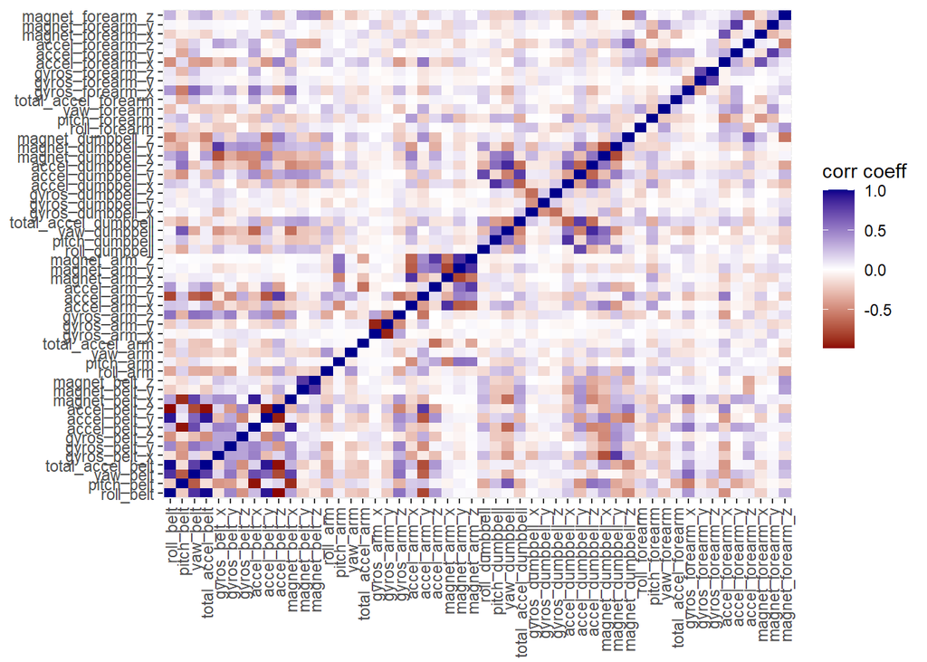

```r
# pairwise correlation matrix of all variables
cor_matrix <- cor(training[sapply(training, is.numeric)])

# transform correlation matrix for plotting
melted_cor_matrix <- melt(cor_matrix)

# plot correlation matrix
ggplot(data = melted_cor_matrix, aes(x=Var1, y=Var2, fill=value)) +
      geom_tile() +
      labs(fill = 'corr coeff')+
      theme(axis.title = element_blank(),
            axis.text.x = element_text(angle = 90, hjust = 1, vjust = 0.5)) +
      scale_fill_gradient2(low = 'darkred', high = 'darkblue', mid = 'white' )
```

Based on the pairwise correlations, some variables appear to be highly correlated (coefficient > 0.9). We will keep only one of them for the prediction.

```r
# find highly correlated variables
cor_var <- findCorrelation(cor_matrix, cutoff = .90)

# remove one of the highly correlated variables in pairs
training <- training[, -cor_var]

# resulting training dataset dimension
dim(training)
```

```
## [1] 13737    48
```

## Model developement

We will develop three different models (Random forest, Gradient Boosting Machine and Linear Discriminant Analysis) and compare their performance before deciding which one works best.

For all models, we instruct the “train” function to use 3-fold cross-validation to select optimal tuning parameters for the model.

### Random Forest (RF)

First, we fit a RF model on `training`.

```r
# instruct train to use 3-fold cross-validation to select optimal tuning parameters
fitControl <- trainControl(method="cv", number=3, verboseIter=F)

# fit random forest model on training
modRF = train(classe~., data = training, method = 'rf', trControl = fitControl,
              tuneLength = 5)
```

### Gradient Boosting Machine (GBM)

Now, we fit a GBM model on `training`.

```r
modGBM = train(classe~., data = training, method = 'gbm', trControl = fitControl,
               tuneLength = 5, verbose = F)
```

### Linear Discriminant Analysis (LDA)

Finally, we fit a LDA model on `training`.

```r
modLDA = train(classe~., data = training, method = 'lda', trControl = fitControl)
```

## Model testing and selection

We use the 3 fitted models to predict the label (“classe”) in `testing`, and show the confusion matrix to compare the predicted versus the actual labels and select the model with best performance.

### RF

```r
# use RF fitted model on testing to predict 'classe'
predRF = predict(modRF, testing)

# show confusion matrix to get accuracy
RFconfMatrix = confusionMatrix(predRF, as.factor(testing$classe))
RFconfMatrix
```

```
## Confusion Matrix and Statistics
##
##           Reference
## Prediction    A    B    C    D    E
##          A 1672    3    0    0    0
##          B    1 1129    4    0    0
##          C    0    7 1022   15    3
##          D    0    0    0  947    0
##          E    1    0    0    2 1079
##
## Overall Statistics
##
##                Accuracy : 0.9939
##                  95% CI : (0.9915, 0.9957)
##     No Information Rate : 0.2845
##     P-Value [Acc > NIR] : < 2.2e-16
##
##                   Kappa : 0.9923
##
##  Mcnemar's Test P-Value : NA
##
## Statistics by Class:
##
##                      Class: A Class: B Class: C Class: D Class: E
## Sensitivity            0.9988   0.9912   0.9961   0.9824   0.9972
## Specificity            0.9993   0.9989   0.9949   1.0000   0.9994
## Pos Pred Value         0.9982   0.9956   0.9761   1.0000   0.9972
## Neg Pred Value         0.9995   0.9979   0.9992   0.9966   0.9994
## Prevalence             0.2845   0.1935   0.1743   0.1638   0.1839
## Detection Rate         0.2841   0.1918   0.1737   0.1609   0.1833
## Detection Prevalence   0.2846   0.1927   0.1779   0.1609   0.1839
## Balanced Accuracy      0.9990   0.9951   0.9955   0.9912   0.9983
```

### GBM

```r
# use GBM fitted model on testing to predict 'classe'
predGBM = predict(modGBM, testing)

# show confusion matrix to get accuracy
GBMconfMatrix = confusionMatrix(predGBM, as.factor(testing$classe))
GBMconfMatrix
```

```
## Confusion Matrix and Statistics
##
##           Reference
## Prediction    A    B    C    D    E
##          A 1671    5    0    0    0
##          B    3 1112    5    0    3
##          C    0   20 1016   16    4
##          D    0    0    5  947    3
##          E    0    2    0    1 1072
##
## Overall Statistics
##
##                Accuracy : 0.9886
##                  95% CI : (0.9856, 0.9912)
##     No Information Rate : 0.2845
##     P-Value [Acc > NIR] : < 2.2e-16
##
##                   Kappa : 0.9856
##
##  Mcnemar's Test P-Value : NA
##
## Statistics by Class:
##
##                      Class: A Class: B Class: C Class: D Class: E
## Sensitivity            0.9982   0.9763   0.9903   0.9824   0.9908
## Specificity            0.9988   0.9977   0.9918   0.9984   0.9994
## Pos Pred Value         0.9970   0.9902   0.9621   0.9916   0.9972
## Neg Pred Value         0.9993   0.9943   0.9979   0.9966   0.9979
## Prevalence             0.2845   0.1935   0.1743   0.1638   0.1839
## Detection Rate         0.2839   0.1890   0.1726   0.1609   0.1822
## Detection Prevalence   0.2848   0.1908   0.1794   0.1623   0.1827
## Balanced Accuracy      0.9985   0.9870   0.9910   0.9904   0.9951
```

### LDA

```r
# use LDA fitted model on testing to predict 'classe'
predLDA = predict(modLDA, testing)

# show confusion matrix to get accuracy
LDAconfMatrix = confusionMatrix(predLDA, as.factor(testing$classe))
LDAconfMatrix
```

```
## Confusion Matrix and Statistics
##
##           Reference
## Prediction    A    B    C    D    E
##          A 1399  190  124   58   52
##          B   47  702   70   79  192
##          C   92  142  673  114  120
##          D  129   33  132  658  103
##          E    7   72   27   55  615
##
## Overall Statistics
##
##                Accuracy : 0.6877
##                  95% CI : (0.6757, 0.6995)
##     No Information Rate : 0.2845
##     P-Value [Acc > NIR] : < 2.2e-16
##
##                   Kappa : 0.604
##
##  Mcnemar's Test P-Value : < 2.2e-16
##
## Statistics by Class:
##
##                      Class: A Class: B Class: C Class: D Class: E
## Sensitivity            0.8357   0.6163   0.6559   0.6826   0.5684
## Specificity            0.8993   0.9182   0.9037   0.9193   0.9665
## Pos Pred Value         0.7674   0.6440   0.5898   0.6237   0.7925
## Neg Pred Value         0.9323   0.9089   0.9256   0.9366   0.9086
## Prevalence             0.2845   0.1935   0.1743   0.1638   0.1839
## Detection Rate         0.2377   0.1193   0.1144   0.1118   0.1045
## Detection Prevalence   0.3098   0.1852   0.1939   0.1793   0.1319
## Balanced Accuracy      0.8675   0.7673   0.7798   0.8009   0.7674
```

### Models Comparison

The table below compares the accury and predicted out-of-sample error in all 3 models.

```r
# create dataframe of models accuracy
models = data.frame(model=c('RF', 'GBM', 'LDA'), accuracy=c(RFconfMatrix$overall[1],
                                                            GBMconfMatrix$overall[1],
                                                            LDAconfMatrix$overall[1]))
# round accuracy to 3 digits
models$accuracy = round(models$accuracy, 3)

# compuate oos error
models$oos_error = 1-models$accuracy

models
```

```
##   model accuracy oos_error
## 1    RF    0.994     0.006
## 2   GBM    0.989     0.011
## 3   LDA    0.688     0.312
```

We will now apply this model on the validation data to predict the ‘classe’ in 20 test cases.

## Predictions in Validation cases

We will use the RF model fitted on `training` to predict the label ‘classe’ for the cases in `validation` dataset.

```r
# apply model on validation
pred = predict(modRF, validation)

# create dataframe with prediction for each case
pred = data.frame(case = c(1:length(pred)), pred = pred)

print(pred)
```

```
##    case pred
## 1     1    B
## 2     2    A
## 3     3    B
## 4     4    A
## 5     5    A
## 6     6    E
## 7     7    D
## 8     8    B
## 9     9    A
## 10   10    A
## 11   11    B
## 12   12    C
## 13   13    B
## 14   14    A
## 15   15    E
## 16   16    E
## 17   17    A
## 18   18    B
## 19   19    B
## 20   20    B
```